# Week 2 — Describing data

Week 1 gave you a centre and a spread. This week adds the two things that make a description usable: **shape**, and a picture.

It also answers the question week 1 left open. You have a sample. Everything you compute from it — a mean, a standard deviation — is a *statistic*, and it would have come out differently with a different sample. How much differently, and how much should that worry you?

```python
import math9102 as m9
import matplotlib.pyplot as plt
import numpy as np
import pandas as pd
from scipy import stats

m9.use_house_style()
```

## Part 1 — From a sample to a population

Suppose you want the mean length of all the fish in a lake.

- That number is a **parameter**: a fixed fact about the population.
- It is almost certainly unknowable — you cannot catch every fish, and the population changes while you try.
- So you catch a sample and compute its mean. That is a **statistic**.

Two people fishing the same lake get different fish, so they get different means. That is **sampling variation**, and it is not a mistake by either of them.

### The sampling distribution

Imagine repeating the sampling many times and collecting all the means. Those means have a distribution of their own — the **sampling distribution of the mean**.

We can simulate exactly that.

```python
rng = np.random.default_rng(0)
population = rng.normal(10, 3, 200_000)

def sample_means(n, reps=4000):
    return rng.choice(population, size=(reps, n)).mean(axis=1)

for n in (6, 25, 100):
    means = sample_means(n)
    print(f"samples of {n:3d}: mean of means = {means.mean():.3f}, "
          f"SD of means = {means.std(ddof=1):.3f}")
```

```
samples of   6: mean of means = 9.978, SD of means = 1.222
samples of  25: mean of means = 9.981, SD of means = 0.595
samples of 100: mean of means = 10.006, SD of means = 0.308
```

Two things to read off:

1. **The mean of the sample means lands on the population mean.** The sample mean is an unbiased estimate — on average, it is right.
2. **The spread of the sample means shrinks as the sample grows.** That spread is the thing we care about, and it has a name.

### Standard error

The **standard error of the mean** is the standard deviation of the sampling distribution. It measures how much a sample mean is likely to move about.

You do not have to simulate it. It has a formula:

```python
for n in (6, 25, 100):
    means = sample_means(n)
    print(f"n = {n:3d}:  simulated SD of means = {means.std(ddof=1):.3f},  "
          f"formula = {population.std(ddof=0) / np.sqrt(n):.3f}")
```

```
n =   6:  simulated SD of means = 1.232,  formula = 1.226
n =  25:  simulated SD of means = 0.603,  formula = 0.601
n = 100:  simulated SD of means = 0.298,  formula = 0.300
```

Note the **square root**. Quadrupling the sample halves the standard error, it does not quarter it. Precision gets more expensive the more of it you buy.

In practice you have one sample, not thousands, so you estimate the standard error from it:

```python
festival = m9.load_festival()
day1 = festival.day1.dropna()

# The corrected copy: the recorded data hold an entry error, which Part 4 finds.
clean = m9.load_festival(with_outlier=False).day1.dropna()

se = clean.std(ddof=1) / np.sqrt(len(clean))
print(f"standard error of the mean = {se:.4f}")
```

```
standard error of the mean = 0.0244
```

**Do not confuse the two.** The standard deviation describes how spread out the *observations* are. The standard error describes how precisely you have pinned down the *mean*. A large dataset of very variable things has a large SD and a small SE.

### The Central Limit Theorem

The simulation above used a normal population, so it is unsurprising that the means came out normal. The Central Limit Theorem says something much stronger.

> **For a sufficiently large sample size, the sampling distribution of the mean is approximately normal — whatever the shape of the population.**

Read that sentence twice, because it is very easy to remember it wrong. Two things it does **not** say:

- It does **not** say your data become normal. The population is whatever it is.
- It does **not** say a fixed sample size is enough for every population. How large "sufficiently large" has to be depends on how far from normal the population is.

Here is all three of those claims, on a strongly skewed population:

```python
skewed = rng.exponential(1.0, 400_000)

print(f"population skew: {stats.skew(skewed):.2f}")
for n in (2, 10, 50, 200):
    means = rng.choice(skewed, size=(6000, n)).mean(axis=1)
    print(f"  mean of {n:3d}: skew of the sampling distribution = {stats.skew(means):.2f}")
```

```
population skew: 2.00
  mean of   2: skew of the sampling distribution = 1.41
  mean of  10: skew of the sampling distribution = 0.62
  mean of  50: skew of the sampling distribution = 0.29
  mean of 200: skew of the sampling distribution = 0.14
```

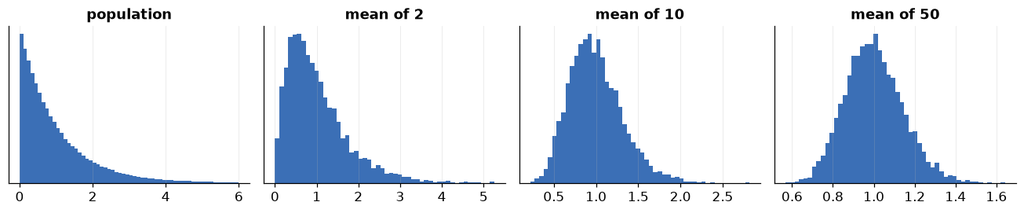

```python
fig, axes = plt.subplots(1, 4, figsize=(12, 2.6))
axes[0].hist(skewed, bins=60, range=(0, 6))
axes[0].set_title("population")
for ax, n in zip(axes[1:], (2, 10, 50)):
    ax.hist(rng.choice(skewed, size=(6000, n)).mean(axis=1), bins=50)
    ax.set_title(f"mean of {n}")
for ax in axes:
    ax.set_yticks([])
fig.tight_layout();
```

The population stays exactly as skewed as it always was. The **sampling distribution** straightens out as the sample grows — and at a sample of two it has barely started.

**Why we care.** Almost every test in this module compares a statistic to a distribution and asks how surprising it is. That reasoning needs the sampling distribution's shape. The CLT is what lets us assume it.

## Part 2 — The normal distribution

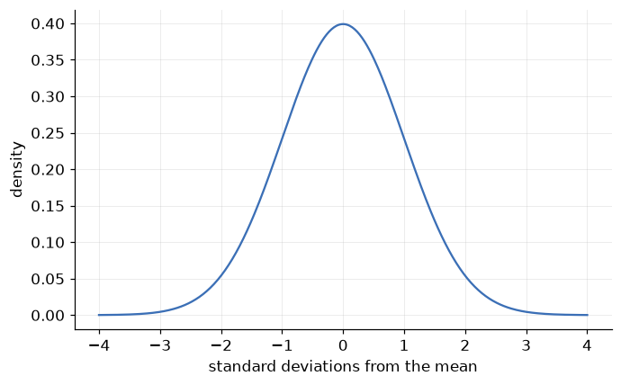

```python
x = np.linspace(-4, 4, 400)
plt.plot(x, stats.norm.pdf(x))
plt.xlabel("standard deviations from the mean")
plt.ylabel("density");
```

Its properties:

- Symmetric about the mean, and bell-shaped.
- The mean, median and mode are the same value.
- It is completely specified by two numbers: the mean and the standard deviation. Nothing else about it can vary.
- It approaches the horizontal axis but never touches it.
- The total area under it is 1, and **area is probability**.

### The empirical rule

```python
for k in (1, 2, 3):
    share = stats.norm.cdf(k) - stats.norm.cdf(-k)
    print(f"within {k} SD of the mean: {share:.4f}")
```

```
within 1 SD of the mean: 0.6827
within 2 SD of the mean: 0.9545
within 3 SD of the mean: 0.9973
```

That is the 68–95–99.7 rule, and now you have seen where it comes from rather than being asked to memorise it.

Does real data obey it?

```python
survey = m9.load_survey()
stress = survey.tpstress.dropna()
z = (stress - stress.mean()) / stress.std(ddof=1)

for k in (1, 2, 3):
    print(f"within {k} SD: observed {(z.abs() <= k).mean():.4f}, "
          f"normal says {stats.norm.cdf(k) - stats.norm.cdf(-k):.4f}")
```

```
within 1 SD: observed 0.7136, normal says 0.6827
within 2 SD: observed 0.9400, normal says 0.9545
within 3 SD: observed 0.9977, normal says 0.9973
```

Close, but not exact — which is the normal state of affairs. The normal distribution is a model, not a description of anything real.

## Part 3 — Standardising, and z-scores

Fred sits two tests and scores the same mark in both. In one the class average was low, in the other it was high. Did he do better in one than the other?

Raw marks cannot answer that. Standardised ones can.

```python
fred = 78
for name, mean, sd in [("Test A", 70, 8), ("Test B", 66, 6)]:
    print(f"{name}: z = {(fred - mean) / sd:.2f}")
```

```
Test A: z = 1.00
Test B: z = 2.00
```

A **z-score** expresses a value as the number of standard deviations it sits from the mean:

$$z = \frac{x - \bar{x}}{s}$$

The set of z-scores has mean zero and standard deviation one, whatever the original units were. That is what makes two different scales comparable.

```python
z = (stress - stress.mean()) / stress.std(ddof=1)
print(f"mean of z = {z.mean():.6f}, SD of z = {z.std(ddof=1):.6f}")
```

```
mean of z = 0.000000, SD of z = 1.000000
```

### Tail probabilities without a table

Textbooks send you to a printed table of areas under the normal curve. You have the function itself.

```python
print(f"P(Z > 2.00) = {stats.norm.sf(2.00):.4f}")
print(f"P(Z > 2.33) = {stats.norm.sf(2.33):.4f}")
print(f"P(|Z| > 1.96) = {2 * stats.norm.sf(1.96):.4f}")
```

```
P(Z > 2.00) = 0.0228
P(Z > 2.33) = 0.0099
P(|Z| > 1.96) = 0.0500
```

A worked question of the kind the tables were for. If 480 scores are normally distributed with a mean of 60 and a standard deviation of 8, how many are 76 or above?

```python
z_76 = (76 - 60) / 8
share = stats.norm.sf(z_76)
print(f"z = {z_76:.2f}, tail area = {share:.4f}, expected count = {share * 480:.1f}")
```

```
z = 2.00, tail area = 0.0228, expected count = 10.9
```

And the head-injury example: someone with a head injury scores 89 on a comprehension test where uninjured people average 92 with a standard deviation of 6. Is that impaired?

```python
z_89 = (89 - 92) / 6
print(f"z = {z_89:.2f}")
print(f"share of uninjured people scoring this low or lower: {stats.norm.cdf(z_89):.4f}")
```

```
z = -0.50
share of uninjured people scoring this low or lower: 0.3085
```

Nearly a third of uninjured people would score at least this low. On this evidence alone, no.

**Note what just happened.** We compared an observation to a distribution and asked how surprising it was. That is the whole logic of the tests in weeks 3 to 5, and you have now done it once by hand.

## Part 4 — Shape

Centre and spread are not enough. Two variables can share both and look nothing alike.

```python
m9.describe(festival, ["day1", "day2", "day3"])
```

|  | n | missing | mean | sd | se | median | iqr | min | max | skew | kurtosis |
| --- | --- | --- | --- | --- | --- | --- | --- | --- | --- | --- | --- |
| day1 | 810 | 0 | 1.793 | 0.944 | 0.033 | 1.79 | 0.918 | 0.02 | 20.02 | 8.865 | 170.450 |
| day2 | 264 | 546 | 0.961 | 0.721 | 0.044 | 0.79 | 0.940 | 0.00 | 3.44 | 1.095 | 0.822 |
| day3 | 123 | 687 | 0.977 | 0.710 | 0.064 | 0.76 | 1.085 | 0.02 | 3.41 | 1.033 | 0.732 |

**Skew** is asymmetry. Positive means a tail to the right, negative a tail to the left, zero means symmetric.

**Kurtosis** is about the tails: how much of the variance comes from rare extreme values rather than typical ones. Both `scipy` and this module report *excess* kurtosis, so zero means "like a normal".

```python
for name, sample in [
    ("normal", rng.normal(0, 1, 20_000)),
    ("right-skewed", rng.gamma(1.6, 1.0, 20_000)),
    ("uniform (light tails)", rng.uniform(-2, 2, 20_000)),
]:
    print(f"{name:24s} skew {stats.skew(sample):+.2f}  kurtosis {stats.kurtosis(sample):+.2f}")
```

```
normal                   skew -0.00  kurtosis +0.02
right-skewed             skew +1.63  kurtosis +4.07
uniform (light tails)    skew -0.01  kurtosis -1.20
```

**Treat both as descriptions of shape.** They are not tests, and we will not use them as pass/fail criteria. Week 3 explains why that matters at this module's sample sizes.

### Outliers

```python
q1, q3 = day1.quantile([0.25, 0.75])
iqr = q3 - q1
fence = q3 + 1.5 * iqr

flagged = day1[day1 > fence]
print(f"upper fence = {fence:.2f}")
print(f"values beyond it: {len(flagged)}, largest = {flagged.max():.2f}")
```

```
upper fence = 3.61
values beyond it: 2, largest = 20.02
```

The hygiene scale runs from 0 to 4. A value of twenty is not an unusually clean festival-goer; it is a data-entry error. Compare:

```python
clean = m9.load_festival(with_outlier=False).day1.dropna()

comparison = pd.DataFrame({
    "as recorded": [day1.mean(), day1.std(ddof=1), day1.median(),
                    day1.quantile(.75) - day1.quantile(.25)],
    "corrected": [clean.mean(), clean.std(ddof=1), clean.median(),
                  clean.quantile(.75) - clean.quantile(.25)],
}, index=["mean", "SD", "median", "IQR"])
comparison.round(3)
```

|  | as recorded | corrected |
| --- | --- | --- |
| mean | 1.793 | 1.771 |
| SD | 0.944 | 0.694 |
| median | 1.790 | 1.790 |
| IQR | 0.918 | 0.918 |

One value out of eight hundred moves the standard deviation substantially and leaves the median and IQR untouched. That is the difference between a **resistant** summary and one that is not.

**A value beyond the fence is not a licence to delete it.** It is an instruction to find out what it is. This one is an error and gets corrected. A genuine extreme value stays, and gets reported.

## Part 5 — Choosing a picture

The rule is short:

| Variable | Plot |
| --- | --- |
| One continuous variable | histogram, or a density plot |
| One continuous variable, compared across groups | boxplots side by side |
| One categorical variable | bar chart, or just a table |
| Two continuous variables | scatterplot (week 3) |

### Histograms, and the bin width

A histogram is not a fact about the data. It is a fact about the data *and* your choice of bin width.

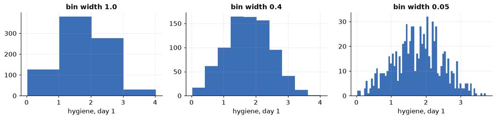

```python
fig, axes = plt.subplots(1, 3, figsize=(12, 3))
for ax, width in zip(axes, (1.0, 0.4, 0.05)):
    ax.hist(clean, bins=np.arange(clean.min(), clean.max() + width, width))
    ax.set_title(f"bin width {width}")
    ax.set_xlabel("hygiene, day 1")
fig.tight_layout();
```

Too wide and you lose the shape; too narrow and you are looking at noise. Try more than one before you believe any of them.

`m9.histogram_with_normal` draws the histogram on the **density** scale with a matching normal curve over it, so the two are comparable:

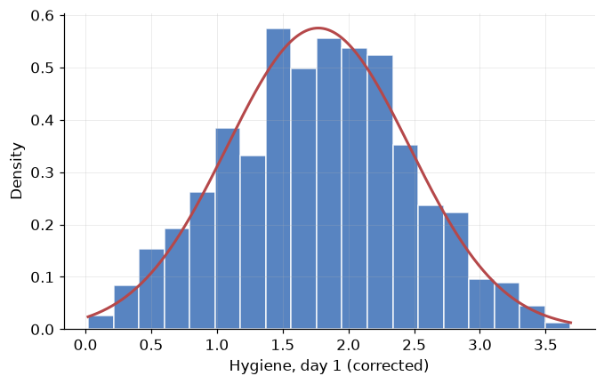

```python
m9.histogram_with_normal(clean, xlabel="Hygiene, day 1 (corrected)");
```

### Density plots

A density plot is a smoothed histogram. The smoothing has a parameter, and it makes the same kind of difference the bin width does:

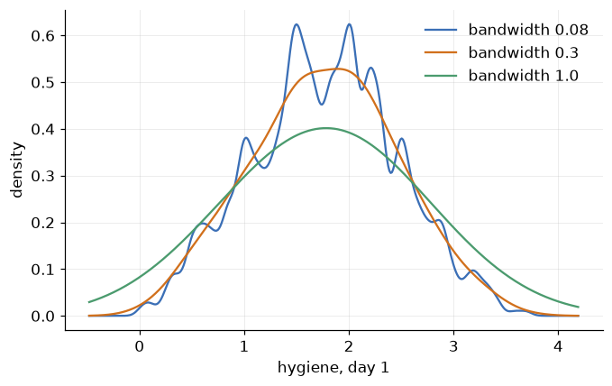

```python
grid = np.linspace(clean.min() - 0.5, clean.max() + 0.5, 400)

for bw in (0.08, 0.3, 1.0):
    plt.plot(grid, stats.gaussian_kde(clean, bw_method=bw)(grid), label=f"bandwidth {bw}")
plt.xlabel("hygiene, day 1")
plt.ylabel("density")
plt.legend();
```

### Boxplots

A boxplot is the five-number summary drawn: minimum, Q1, median, Q3, maximum, with anything beyond the fences plotted individually.

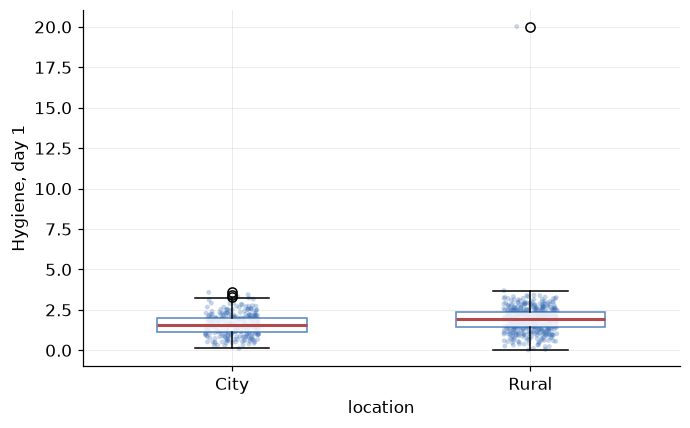

```python
m9.grouped_box(festival, "day1", "location", ylabel="Hygiene, day 1");
```

Read it in this order: where the median sits inside the box (off-centre means skew), how tall the box is (that is the IQR), how long the whiskers are, and what is beyond them.

### Bar charts, and one to avoid

For a categorical variable, a bar chart of counts:

```python
romcom = m9.load_romcom()
m9.frequency(romcom, "film")
```

| film | count | percent | valid_percent |
| --- | --- | --- | --- |
| Bridget Jones' Diary | 20 | 50.0 | 50.0 |
| Memento | 20 | 50.0 | 50.0 |

You will also see bar charts of **group means**. Avoid them.

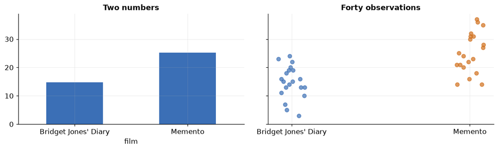

```python
fig, axes = plt.subplots(1, 2, figsize=(11, 3.4), sharey=True)

romcom.groupby("film").interest.mean().plot.bar(ax=axes[0], rot=0)
axes[0].set_title("Two numbers")

jitter = np.random.default_rng(1)
films = romcom.groupby("film").interest
for i, (film, values) in enumerate(films):
    axes[1].scatter(i + jitter.uniform(-0.08, 0.08, len(values)), values, alpha=0.7)
axes[1].set_xticks(range(films.ngroups), [film for film, _ in films])
axes[1].set_title("Forty observations")
fig.tight_layout();
```

Both panels show the same data. The left one shows two numbers and hides the spread, the group sizes and the overlap. The right one, a dot plot, shows every observation — and so all three, for about the same amount of ink.

## Part 6 — Describing a whole dataset

Everything above is per variable. Now the report your reader actually needs.

```python
survey = m9.load_survey()
survey.shape
```

```
(439, 134)
```

The Melbourne wellbeing survey: responses from members of the general public, measured on validated scales for self-esteem, optimism, perceived control, perceived stress, positive and negative affect, and life satisfaction, plus a social-desirability scale and demographics.

### Step 1: what question are you answering?

> Does optimism predict life satisfaction, once perceived stress and self-esteem are taken into account?

That question names four variables. Describe **those**, together with the demographics that say who the respondents were — not all 134 columns.

```python
model_vars = ["toptim", "tpstress", "tlifesat", "tslfest"]
```

### Step 2: type every variable you will use

```python
m9.md("""
| Variable | Concept | Level of measurement |
|---|---|---|
| `sex` | Gender | nominal |
| `age` | Age in years | ratio |
| `child` | Has children | nominal |
| `educ` | Highest level of education completed | **ordinal** |
| `smoke` | Smoker | nominal |
| `toptim` | Optimism, six-item Life Orientation Test total | interval, treated as scale |
| `tpstress` | Perceived Stress Scale total, ten items | interval, treated as scale |
| `tlifesat` | Satisfaction With Life total, five items | interval, treated as scale |
| `tslfest` | Rosenberg Self-Esteem total, ten items | interval, treated as scale |
""")
```

| Variable | Concept | Level of measurement |
| --- | --- | --- |
| `sex` | Gender | nominal |
| `age` | Age in years | ratio |
| `child` | Has children | nominal |
| `educ` | Highest level of education completed | **ordinal** |
| `smoke` | Smoker | nominal |
| `toptim` | Optimism, six-item Life Orientation Test total | interval, treated as scale |
| `tpstress` | Perceived Stress Scale total, ten items | interval, treated as scale |
| `tlifesat` | Satisfaction With Life total, five items | interval, treated as scale |
| `tslfest` | Rosenberg Self-Esteem total, ten items | interval, treated as scale |

Two of those deserve a note.

**`educ` is ordinal**, not nominal. The categories are ranked. Software will not know that: the labels are stored as text, so every table sorts them alphabetically. Step 3 shows it, and fixes it.

**`age` is ratio as recorded here** — whole years, with a true zero. The same concept collected in bands (18–29, 30–44, 45 and over) would be ordinal. The level belongs to the measurement, not to the concept.

**The scale totals are sums of ordinal Likert items.** Strictly, adding ordinal items does not produce an interval measure. In practice, validated psychometric scales are treated as continuous, and the whole literature does so. That is a defensible convention rather than a mathematical fact, and you should be able to say which it is.

### Step 3: describe the categorical variables

```python
for col in ["sex", "child", "smoke"]:
    display(m9.frequency(survey, col))
```

| sex | count | percent | valid_percent |
| --- | --- | --- | --- |
| FEMALES | 254 | 57.86 | 57.86 |
| MALES | 185 | 42.14 | 42.14 |

| child | count | percent | valid_percent |
| --- | --- | --- | --- |
| NO | 253 | 57.63 | 57.76 |
| YES | 185 | 42.14 | 42.24 |
| NaN | 1 | 0.23 | NaN |

| smoke | count | percent | valid_percent |
| --- | --- | --- | --- |
| NO | 351 | 79.95 | 80.5 |
| YES | 85 | 19.36 | 19.5 |
| NaN | 3 | 0.68 | NaN |

```python
m9.frequency(survey, "educ")
```

| educ | count | percent | valid_percent |
| --- | --- | --- | --- |
| COMPLETED HIGHSCHOOL | 85 | 19.36 | 19.36 |
| COMPLETED UNDERGRADUATE | 123 | 28.02 | 28.02 |
| POSTGRADUATE COMPLETED | 56 | 12.76 | 12.76 |
| PRIMARY | 2 | 0.46 | 0.46 |
| SOME ADDITIONAL TRAINING | 120 | 27.33 | 27.33 |
| SOME SECONDARY | 53 | 12.07 | 12.07 |

Alphabetical, because the labels are text — so "primary" sits between "postgraduate" and "some additional training". The real order comes from the questionnaire, and you have to impose it:

```python
education_order = ["PRIMARY", "SOME SECONDARY", "COMPLETED HIGHSCHOOL",
                   "SOME ADDITIONAL TRAINING", "COMPLETED UNDERGRADUATE",
                   "POSTGRADUATE COMPLETED"]
survey["educ"] = pd.Categorical(survey.educ, categories=education_order, ordered=True)
m9.frequency(survey, "educ")
```

| educ | count | percent | valid_percent |
| --- | --- | --- | --- |
| PRIMARY | 2 | 0.46 | 0.46 |
| SOME SECONDARY | 53 | 12.07 | 12.07 |
| COMPLETED HIGHSCHOOL | 85 | 19.36 | 19.36 |
| SOME ADDITIONAL TRAINING | 120 | 27.33 | 27.33 |
| COMPLETED UNDERGRADUATE | 123 | 28.02 | 28.02 |
| POSTGRADUATE COMPLETED | 56 | 12.76 | 12.76 |

### Step 4: describe the continuous variables

```python
m9.describe(survey, ["age"] + model_vars)
```

|  | n | missing | mean | sd | se | median | iqr | min | max | skew | kurtosis |
| --- | --- | --- | --- | --- | --- | --- | --- | --- | --- | --- | --- |
| age | 439 | 0 | 37.437 | 13.202 | 0.630 | 36.0 | 21.0 | 18.0 | 82.0 | 0.606 | -0.203 |
| toptim | 435 | 4 | 22.117 | 4.429 | 0.212 | 22.0 | 7.0 | 7.0 | 30.0 | -0.494 | 0.214 |
| tpstress | 433 | 6 | 26.727 | 5.848 | 0.281 | 26.0 | 8.0 | 12.0 | 46.0 | 0.245 | 0.182 |
| tlifesat | 436 | 3 | 22.378 | 6.770 | 0.324 | 23.0 | 9.0 | 5.0 | 35.0 | -0.323 | -0.450 |
| tslfest | 436 | 3 | 33.532 | 5.395 | 0.258 | 35.0 | 8.0 | 18.0 | 40.0 | -0.876 | 0.061 |

### Step 5: say what is missing

```python
missing = m9.missingness(survey, model_vars)
print(missing.attrs["summary"])
missing
```

```
Listwise deletion across these 4 column(s) keeps 430 of 439 rows (loses 9, 2.1%).
```

|  | column | missing | percent |
| --- | --- | --- | --- |
| 0 | tpstress | 6 | 1.37 |
| 1 | toptim | 4 | 0.91 |
| 2 | tlifesat | 3 | 0.68 |
| 3 | tslfest | 3 | 0.68 |

### Step 6: write it

A description your reader can act on covers:

1. **Who** the participants were, and how they were identified.
2. **How** they were sampled — invited, self-selected, incentivised? Was this secondary data, and if so what is known about its collection?
3. **What** was measured, with what instrument, and what is known about that instrument's validity and reliability.
4. **Each variable** you will use: its level of measurement, how much of it you have, and its summary statistics.
5. **What is missing**, and what that costs.

```python
m9.md(f"""
This analysis uses data condensed by Julie Pallant from a study of the factors
affecting psychological adjustment and wellbeing. A survey containing validated
scales for self-esteem, optimism, perceived control, perceived stress, positive
and negative affect and life satisfaction was distributed to members of the
general public in Melbourne, Australia and surrounding districts. Participation
was voluntary, so the sample is self-selected and cannot be assumed
representative of the Melbourne population.

The dataset contains {len(survey)} responses on {survey.shape[1]} variables.
Respondents' ages range from {survey.age.min():.0f} to {survey.age.max():.0f}
(median {survey.age.median():.0f}). The four variables used in this analysis are
complete for {survey[model_vars].dropna().shape[0]} respondents; listwise
deletion across them loses
{len(survey) - survey[model_vars].dropna().shape[0]} cases.
""")
```

This analysis uses data condensed by Julie Pallant from a study of the factors affecting psychological adjustment and wellbeing. A survey containing validated scales for self-esteem, optimism, perceived control, perceived stress, positive and negative affect and life satisfaction was distributed to members of the general public in Melbourne, Australia and surrounding districts. Participation was voluntary, so the sample is self-selected and cannot be assumed representative of the Melbourne population.

The dataset contains 439 responses on 134 variables. Respondents' ages range from 18 to 82 (median 36). The four variables used in this analysis are complete for 430 respondents; listwise deletion across them loses 9 cases.

Every number in that paragraph was generated. Change the data, run it again, and the paragraph changes with it. **This is the standard for every description you write.**

## What to take from this week

- A statistic varies from sample to sample. The **standard error** measures how much, and it shrinks with the square root of the sample size.
- The **Central Limit Theorem** is about the sampling distribution of the mean, not about your data, and "large enough" depends on the population.
- **Standardising** puts different scales on one ruler and turns a value into a probability.
- Describe **centre, spread and shape** — and look at the shape before choosing the centre.
- A histogram's bin width and a density plot's bandwidth are **your choices**. Try several.
- An outlier is something to investigate, not something to delete.
- Describe the variables your question needs, not every column you were given.

## Exercise

`exercise.md` gives you a variable with a known problem in it and asks you to describe it properly.